# Analysis of SyriaTel performance in the Telecommunication Industry

# Business Understanding

The telecommunication industry is faced with one of the fiercest competitions globally. Customers are in need of the cheapest, reliable and safe communication platforms.This study focuses on SyriaTel, a telecommunications company in Syria.Among the challenges facing this company include;Intense Competition,Service Quality Issues (Network Coverage and Reliability),Economic and Political Instability, Changing Customer Expectations,Pricing and Plan Flexibility,Customer Satisfaction and Perception,Regulatory Environment (Government Regulations),Inability to Predict Churn Patterns (Data Analysis Challenges and Lack of Insight into Customer Behavior. This study attempts to guide the mangement of SyriaTel on what areas to improve on in order to bring the company back to profitability.

# Business Problem

Syria Tel intends to turnaround their profitability. The management wants to esbablish roote causes of the challenges and how to address them. The business environment is competetive and the country is rocked with civil wars. The company is hopeful to navigate all these with a proper data analysis and recommendation. This study therefore focusses on customer behaviour with relation to the cost of call and messages, the duration of call and whether the costs should vary between days and nights.

# Data sources

SyriaTel Customer Churn Provides detailed data on various aspects of analysis including; account length, area code,phone number, international plan, voice mail plan,number of vmail messages, total day minutes, total day calls, total day charge, total eve calls, total eve charge, total night minutes, total night calls, total night charge and so on.

# Objectives

The objective of this study is to guide SyriaTel, based on analysis of the above data, how to respond to the changing market and political landscape in Syria.

# Data Understanding

```python
# Importing libraries
import pandas as pd
import numpy as np
import matplotlib.pyplot as plt
import seaborn as sns
import warnings
from sklearn.linear_model import LogisticRegression
from sklearn.ensemble import RandomForestClassifier
from sklearn.svm import SVC
from sklearn.metrics import accuracy_score, precision_score, recall_score, f1_score, roc_auc_score, confusion_matrix
from sklearn.model_selection import cross_val_score
from sklearn.metrics import roc_curve, auc


warnings.filterwarnings('ignore')
```

```python
df= pd.read_csv('archive (1).zip')
df
```

|  | state | account length | area code | phone number | international plan | voice mail plan | number vmail messages | total day minutes | total day calls | total day charge | ... | total eve calls | total eve charge | total night minutes | total night calls | total night charge | total intl minutes | total intl calls | total intl charge | customer service calls | churn |
| --- | --- | --- | --- | --- | --- | --- | --- | --- | --- | --- | --- | --- | --- | --- | --- | --- | --- | --- | --- | --- | --- |
| 0 | KS | 128 | 415 | 382-4657 | no | yes | 25 | 265.1 | 110 | 45.07 | ... | 99 | 16.78 | 244.7 | 91 | 11.01 | 10.0 | 3 | 2.70 | 1 | False |
| 1 | OH | 107 | 415 | 371-7191 | no | yes | 26 | 161.6 | 123 | 27.47 | ... | 103 | 16.62 | 254.4 | 103 | 11.45 | 13.7 | 3 | 3.70 | 1 | False |
| 2 | NJ | 137 | 415 | 358-1921 | no | no | 0 | 243.4 | 114 | 41.38 | ... | 110 | 10.30 | 162.6 | 104 | 7.32 | 12.2 | 5 | 3.29 | 0 | False |
| 3 | OH | 84 | 408 | 375-9999 | yes | no | 0 | 299.4 | 71 | 50.90 | ... | 88 | 5.26 | 196.9 | 89 | 8.86 | 6.6 | 7 | 1.78 | 2 | False |
| 4 | OK | 75 | 415 | 330-6626 | yes | no | 0 | 166.7 | 113 | 28.34 | ... | 122 | 12.61 | 186.9 | 121 | 8.41 | 10.1 | 3 | 2.73 | 3 | False |
| ... | ... | ... | ... | ... | ... | ... | ... | ... | ... | ... | ... | ... | ... | ... | ... | ... | ... | ... | ... | ... | ... |
| 3328 | AZ | 192 | 415 | 414-4276 | no | yes | 36 | 156.2 | 77 | 26.55 | ... | 126 | 18.32 | 279.1 | 83 | 12.56 | 9.9 | 6 | 2.67 | 2 | False |
| 3329 | WV | 68 | 415 | 370-3271 | no | no | 0 | 231.1 | 57 | 39.29 | ... | 55 | 13.04 | 191.3 | 123 | 8.61 | 9.6 | 4 | 2.59 | 3 | False |
| 3330 | RI | 28 | 510 | 328-8230 | no | no | 0 | 180.8 | 109 | 30.74 | ... | 58 | 24.55 | 191.9 | 91 | 8.64 | 14.1 | 6 | 3.81 | 2 | False |
| 3331 | CT | 184 | 510 | 364-6381 | yes | no | 0 | 213.8 | 105 | 36.35 | ... | 84 | 13.57 | 139.2 | 137 | 6.26 | 5.0 | 10 | 1.35 | 2 | False |
| 3332 | TN | 74 | 415 | 400-4344 | no | yes | 25 | 234.4 | 113 | 39.85 | ... | 82 | 22.60 | 241.4 | 77 | 10.86 | 13.7 | 4 | 3.70 | 0 | False |

3333 rows × 21 columns

```python
df.head
```

```
<bound method NDFrame.head of      state  account length  area code phone number international plan  \
0       KS             128        415     382-4657                 no
1       OH             107        415     371-7191                 no
2       NJ             137        415     358-1921                 no
3       OH              84        408     375-9999                yes
4       OK              75        415     330-6626                yes
...    ...             ...        ...          ...                ...
3328    AZ             192        415     414-4276                 no
3329    WV              68        415     370-3271                 no
3330    RI              28        510     328-8230                 no
3331    CT             184        510     364-6381                yes
3332    TN              74        415     400-4344                 no

     voice mail plan  number vmail messages  total day minutes  \
0                yes                     25              265.1
```

[output cut: 64 more lines]

```python
df.describe()
```

|  | account length | area code | number vmail messages | total day minutes | total day calls | total day charge | total eve minutes | total eve calls | total eve charge | total night minutes | total night calls | total night charge | total intl minutes | total intl calls | total intl charge | customer service calls |
| --- | --- | --- | --- | --- | --- | --- | --- | --- | --- | --- | --- | --- | --- | --- | --- | --- |
| count | 3333.000000 | 3333.000000 | 3333.000000 | 3333.000000 | 3333.000000 | 3333.000000 | 3333.000000 | 3333.000000 | 3333.000000 | 3333.000000 | 3333.000000 | 3333.000000 | 3333.000000 | 3333.000000 | 3333.000000 | 3333.000000 |
| mean | 101.064806 | 437.182418 | 8.099010 | 179.775098 | 100.435644 | 30.562307 | 200.980348 | 100.114311 | 17.083540 | 200.872037 | 100.107711 | 9.039325 | 10.237294 | 4.479448 | 2.764581 | 1.562856 |
| std | 39.822106 | 42.371290 | 13.688365 | 54.467389 | 20.069084 | 9.259435 | 50.713844 | 19.922625 | 4.310668 | 50.573847 | 19.568609 | 2.275873 | 2.791840 | 2.461214 | 0.753773 | 1.315491 |
| min | 1.000000 | 408.000000 | 0.000000 | 0.000000 | 0.000000 | 0.000000 | 0.000000 | 0.000000 | 0.000000 | 23.200000 | 33.000000 | 1.040000 | 0.000000 | 0.000000 | 0.000000 | 0.000000 |
| 25% | 74.000000 | 408.000000 | 0.000000 | 143.700000 | 87.000000 | 24.430000 | 166.600000 | 87.000000 | 14.160000 | 167.000000 | 87.000000 | 7.520000 | 8.500000 | 3.000000 | 2.300000 | 1.000000 |
| 50% | 101.000000 | 415.000000 | 0.000000 | 179.400000 | 101.000000 | 30.500000 | 201.400000 | 100.000000 | 17.120000 | 201.200000 | 100.000000 | 9.050000 | 10.300000 | 4.000000 | 2.780000 | 1.000000 |
| 75% | 127.000000 | 510.000000 | 20.000000 | 216.400000 | 114.000000 | 36.790000 | 235.300000 | 114.000000 | 20.000000 | 235.300000 | 113.000000 | 10.590000 | 12.100000 | 6.000000 | 3.270000 | 2.000000 |
| max | 243.000000 | 510.000000 | 51.000000 | 350.800000 | 165.000000 | 59.640000 | 363.700000 | 170.000000 | 30.910000 | 395.000000 | 175.000000 | 17.770000 | 20.000000 | 20.000000 | 5.400000 | 9.000000 |

```python
df.info()
```

```
<class 'pandas.core.frame.DataFrame'>
RangeIndex: 3333 entries, 0 to 3332
Data columns (total 21 columns):
 #   Column                  Non-Null Count  Dtype
---  ------                  --------------  -----
 0   state                   3333 non-null   object
 1   account length          3333 non-null   int64
 2   area code               3333 non-null   int64
 3   phone number            3333 non-null   object
 4   international plan      3333 non-null   object
 5   voice mail plan         3333 non-null   object
 6   number vmail messages   3333 non-null   int64
 7   total day minutes       3333 non-null   float64
 8   total day calls         3333 non-null   int64
 9   total day charge        3333 non-null   float64
 10  total eve minutes       3333 non-null   float64
 11  total eve calls         3333 non-null   int64
 12  total eve charge        3333 non-null   float64
 13  total night minutes     3333 non-null   float64
 14  total night calls       3333 non-null   int64
 15  total night charge      3333 non-null   float64
 16  total intl minutes      3333 non-null   float64
 17  total intl calls        3333 non-null   int64
 18  total intl charge       3333 non-null   float64
 19  customer service calls  3333 non-null   int64
 20  churn                   3333 non-null   bool
dtypes: bool(1), float64(8), int64(8), object(4)
memory usage: 524.2+ KB
```

# Data cleaning

Handling NAs

```python
# CHeck NAs
df.isna().mean()*100
```

```
state                     0.0
account length            0.0
area code                 0.0
phone number              0.0
international plan        0.0
voice mail plan           0.0
number vmail messages     0.0
total day minutes         0.0
total day calls           0.0
total day charge          0.0
total eve minutes         0.0
total eve calls           0.0
total eve charge          0.0
total night minutes       0.0
total night calls         0.0
total night charge        0.0
total intl minutes        0.0
total intl calls          0.0
total intl charge         0.0
customer service calls    0.0
churn                     0.0
dtype: float64
```

```python
# Drop NAs
df.dropna(inplace =True)
df.isna().sum()
```

```
state                     0
account length            0
area code                 0
phone number              0
international plan        0
voice mail plan           0
number vmail messages     0
total day minutes         0
total day calls           0
total day charge          0
total eve minutes         0
total eve calls           0
total eve charge          0
total night minutes       0
total night calls         0
total night charge        0
total intl minutes        0
total intl calls          0
total intl charge         0
customer service calls    0
churn                     0
dtype: int64
```

Handling duplicates

```python
df[df.duplicated()].count()
```

```
state                     0
account length            0
area code                 0
phone number              0
international plan        0
voice mail plan           0
number vmail messages     0
total day minutes         0
total day calls           0
total day charge          0
total eve minutes         0
total eve calls           0
total eve charge          0
total night minutes       0
total night calls         0
total night charge        0
total intl minutes        0
total intl calls          0
total intl charge         0
customer service calls    0
churn                     0
dtype: int64
```

```python
df.drop_duplicates(inplace = True)
df.info()
```

```
<class 'pandas.core.frame.DataFrame'>
RangeIndex: 3333 entries, 0 to 3332
Data columns (total 21 columns):
 #   Column                  Non-Null Count  Dtype
---  ------                  --------------  -----
 0   state                   3333 non-null   object
 1   account length          3333 non-null   int64
 2   area code               3333 non-null   int64
 3   phone number            3333 non-null   object
 4   international plan      3333 non-null   object
 5   voice mail plan         3333 non-null   object
 6   number vmail messages   3333 non-null   int64
 7   total day minutes       3333 non-null   float64
 8   total day calls         3333 non-null   int64
 9   total day charge        3333 non-null   float64
 10  total eve minutes       3333 non-null   float64
 11  total eve calls         3333 non-null   int64
 12  total eve charge        3333 non-null   float64
 13  total night minutes     3333 non-null   float64
 14  total night calls       3333 non-null   int64
 15  total night charge      3333 non-null   float64
 16  total intl minutes      3333 non-null   float64
 17  total intl calls        3333 non-null   int64
 18  total intl charge       3333 non-null   float64
 19  customer service calls  3333 non-null   int64
 20  churn                   3333 non-null   bool
dtypes: bool(1), float64(8), int64(8), object(4)
memory usage: 524.2+ KB
```

```python
df[df.duplicated(subset='area code')].count()
```

```
state                     3330
account length            3330
area code                 3330
phone number              3330
international plan        3330
voice mail plan           3330
number vmail messages     3330
total day minutes         3330
total day calls           3330
total day charge          3330
total eve minutes         3330
total eve calls           3330
total eve charge          3330
total night minutes       3330
total night calls         3330
total night charge        3330
total intl minutes        3330
total intl calls          3330
total intl charge         3330
customer service calls    3330
churn                     3330
dtype: int64
```

```python
for i in df.columns:
  print(f' Unique values for {i}')
  print(f' N-unique values for {i} is {df[i].nunique()}')
  print(list(df[i].unique())) # sort to identify duplicates within column
  print('')
```

[output not shown]

[output cut: 28 more lines]

```
 Unique values for total intl calls
 N-unique values for total intl calls is 21
[3, 5, 7, 6, 4, 2, 9, 19, 1, 10, 15, 8, 11, 0, 12, 13, 18, 14, 16, 20, 17]

 Unique values for total intl charge
 N-unique values for total intl charge is 162
[2.7, 3.7, 3.29, 1.78, 2.73, 1.7, 2.03, 1.92, 2.35, 3.02, 3.43, 2.46, 3.32, 3.54, 1.46, 3.73, 2.19, 3.51, 2.86, 1.54, 2.57, 2.08, 2.78, 4.19, 3.97, 3.0, 3.83, 3.4, 3.19, 2.24, 3.92, 2.84, 2.54, 3.94, 2.48, 0.95, 2.3, 3.56, 2.0, 2.38, 2.97, 2.11, 1.84, 3.08, 2.51, 2.62, 2.75, 2.16, 1.57, 3.27, 3.24, …

 Unique values for customer service calls
 N-unique values for customer service calls is 10
[1, 0, 2, 3, 4, 5, 7, 9, 6, 8]

 Unique values for churn
 N-unique values for churn is 2
[False, True]
```

Other cleaning steps

[figure not shown]

```python
# Outliers

  # Feature engineering

sns.boxplot(df)
```

EDA

Histograms for Numerical Columns

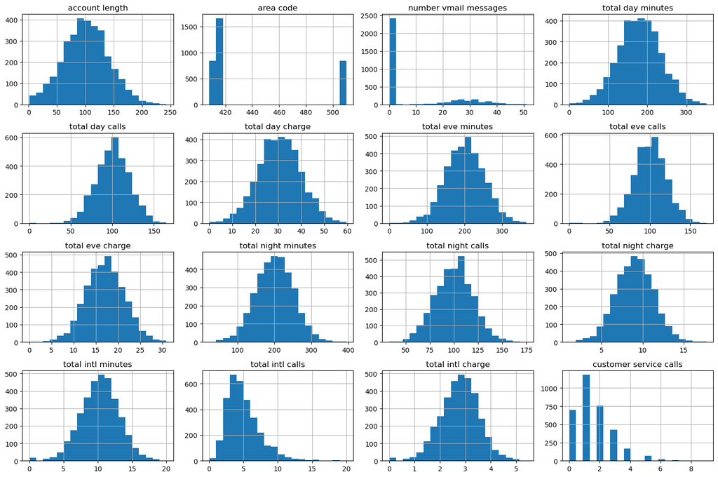

```python
# Plot histograms for numeric columns
numeric_columns = df.select_dtypes(include=['float64', 'int64']).columns

df[numeric_columns].hist(bins=20, figsize=(15, 10))
plt.tight_layout()
plt.show()
```

Boxplots for Outliers

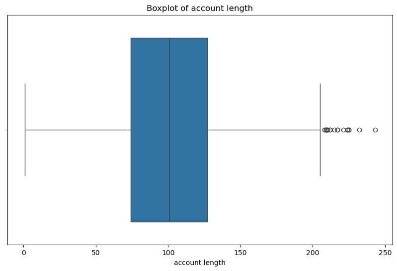

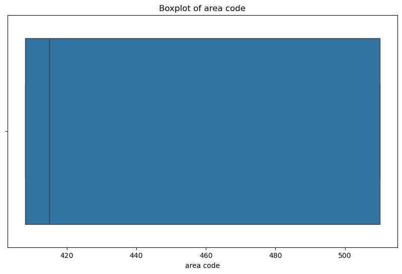

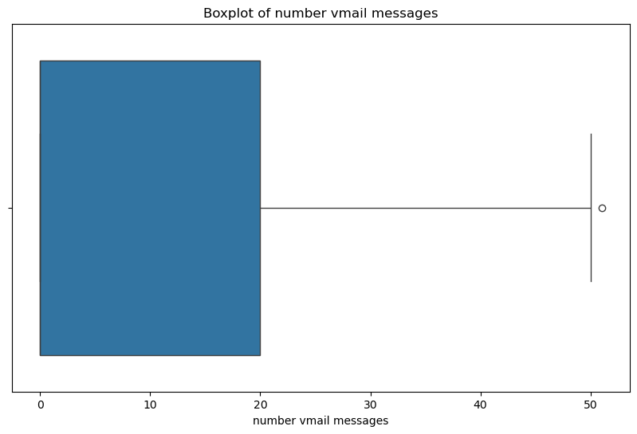

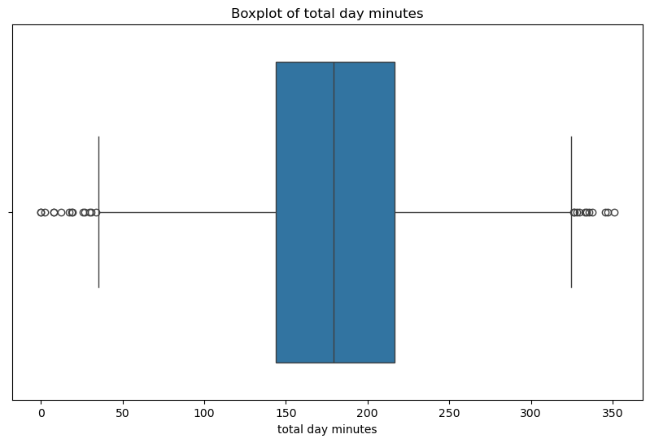

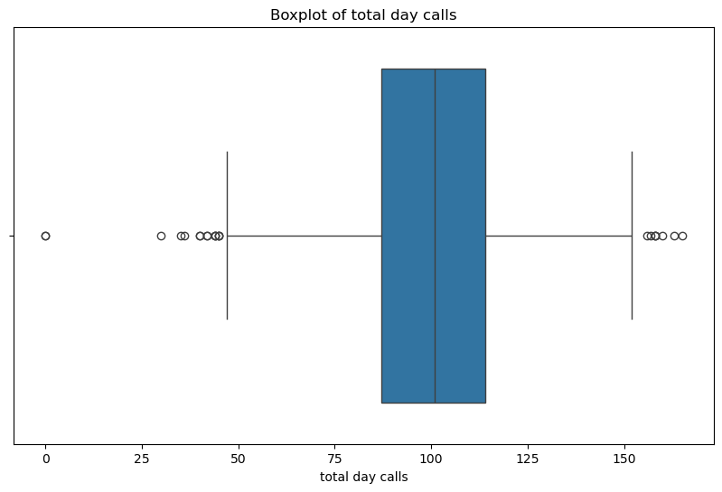

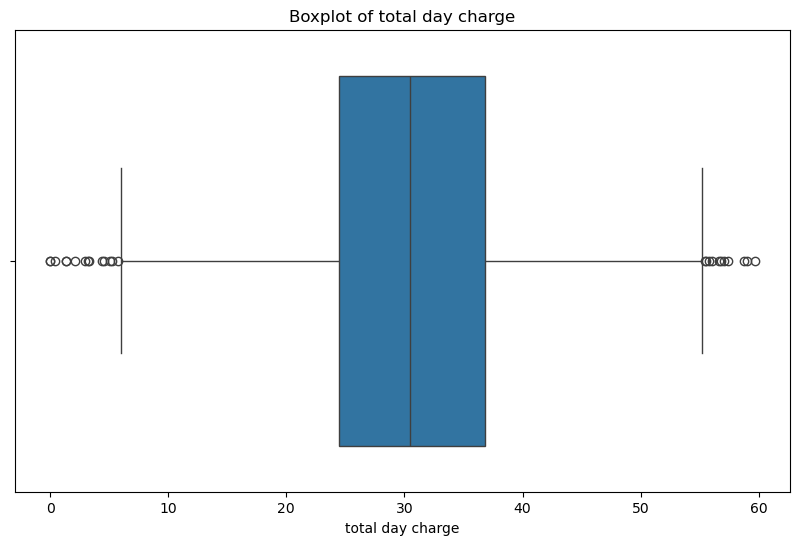

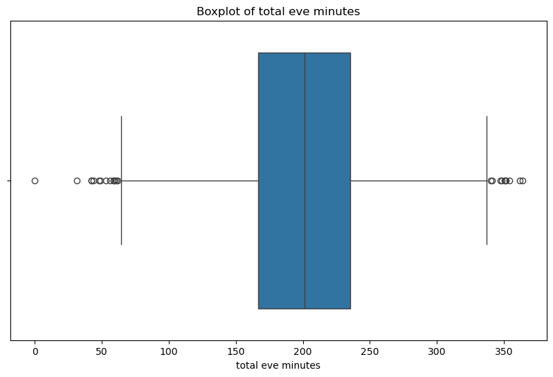

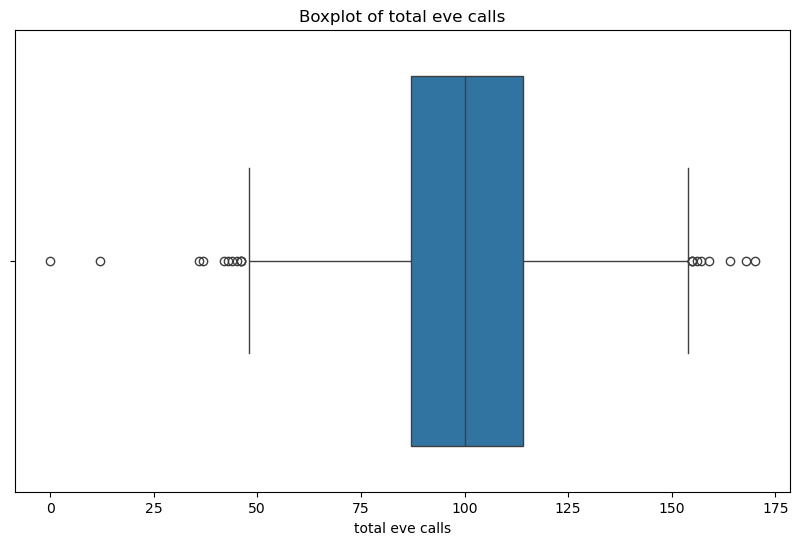

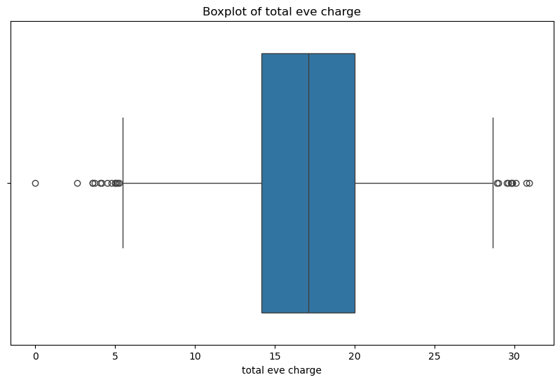

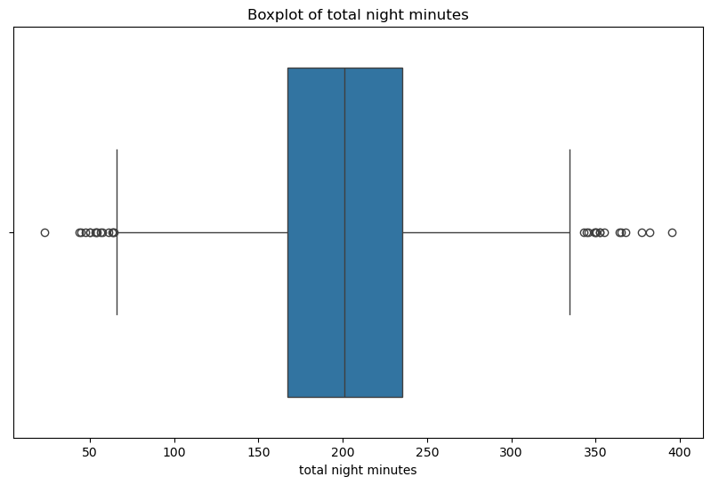

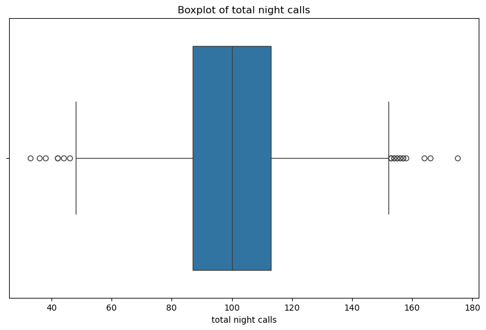

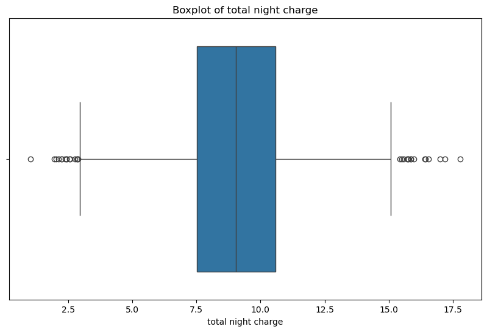

[4 more figures not shown]

```python
# Boxplot for each numeric column
for column in numeric_columns:
    plt.figure(figsize=(10, 6))
    sns.boxplot(x=df[column])
    plt.title(f'Boxplot of {column}')
    plt.show()
```

```python
 # Categorical Data Analysis
```

```python
# Frequency count for categorical columns
categorical_columns = df.select_dtypes(include=['object', 'bool']).columns

for column in categorical_columns:
    print(f'{column} value counts:')
    print(df[column].value_counts())
    print('-' * 40)
```

```
state value counts:
state
WV    106
MN     84
NY     83
AL     80
WI     78
OH     78
OR     78
WY     77
VA     77
CT     74
MI     73
ID     73
VT     73
TX     72
UT     72
IN     71
MD     70
KS     70
NC     68
NJ     68
MT     68
CO     66
NV     66
WA     66
RI     65
MA     65
MS     65
AZ     64
FL     63
MO     63
NM     62
ME     62
ND     62
NE     61
OK     61
DE     61
SC     60
SD     60
```

[output cut: 33 more lines]

```
yes     323
Name: count, dtype: int64
----------------------------------------
voice mail plan value counts:
voice mail plan
no     2411
yes     922
Name: count, dtype: int64
----------------------------------------
churn value counts:
churn
False    2850
True      483
Name: count, dtype: int64
----------------------------------------
```

Bar Plots for Categorical Variables

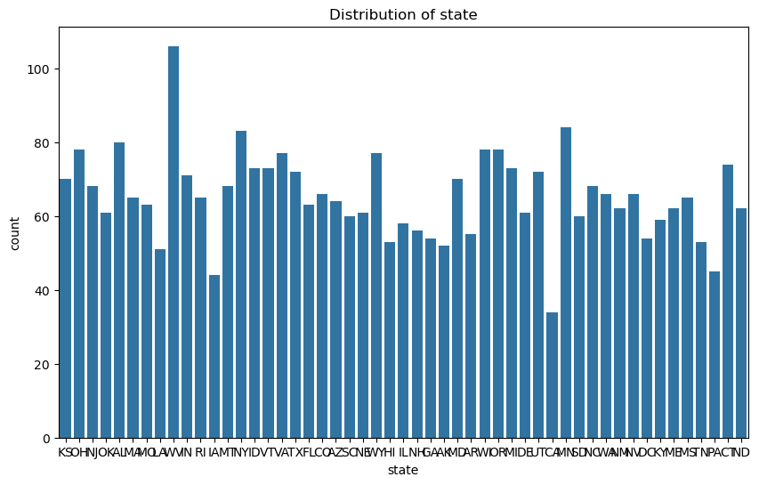

[figure not shown]

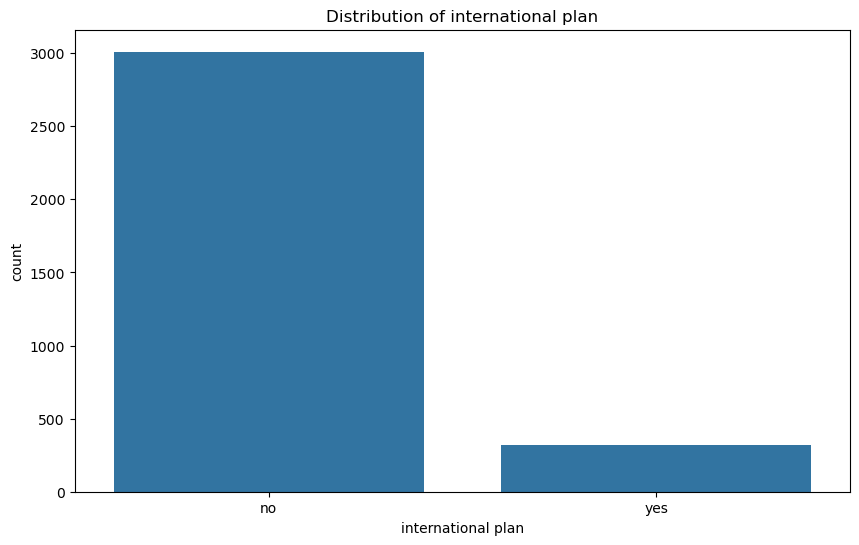

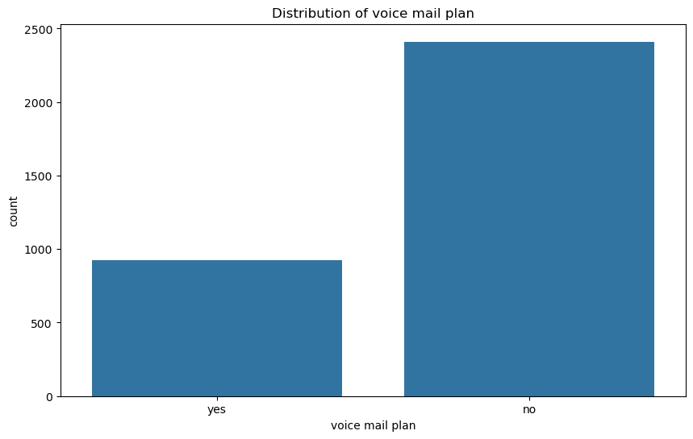

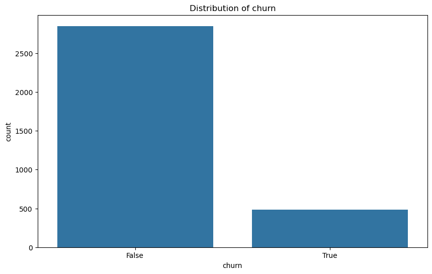

```python
# Bar plot for categorical columns
for column in categorical_columns:
    plt.figure(figsize=(10, 6))
    sns.countplot(data=df, x=column)
    plt.title(f'Distribution of {column}')
    plt.show()
```

Correlation Analysis

Correlation Matrix

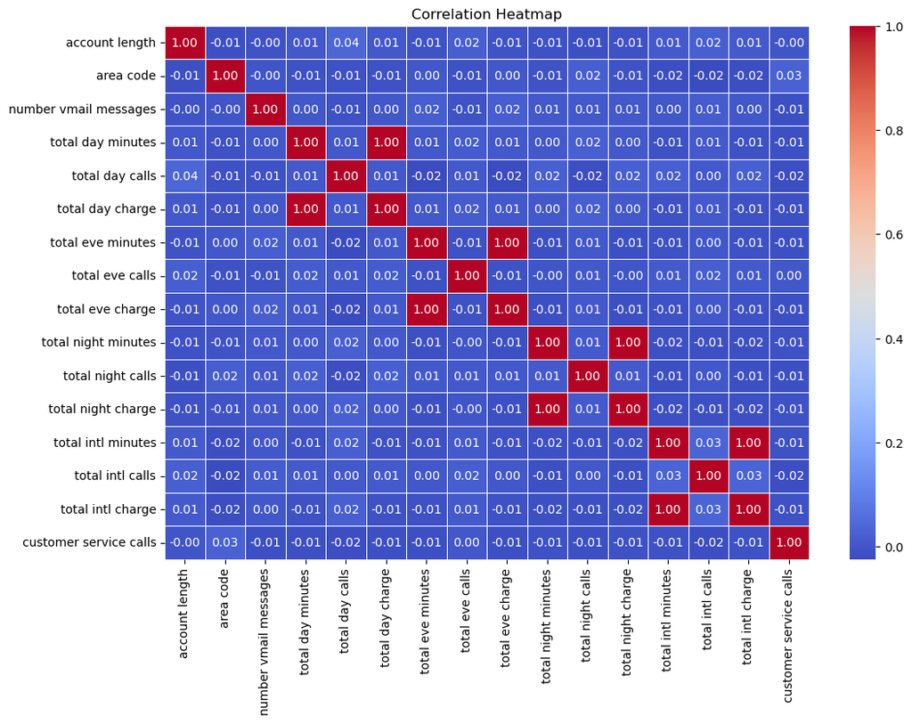

```python
# Correlation heatmap
corr = df[numeric_columns].corr()
plt.figure(figsize=(12, 8))
sns.heatmap(corr, annot=True, cmap='coolwarm', fmt='.2f', linewidths=0.5)
plt.title('Correlation Heatmap')
plt.show()
```

Pairplot

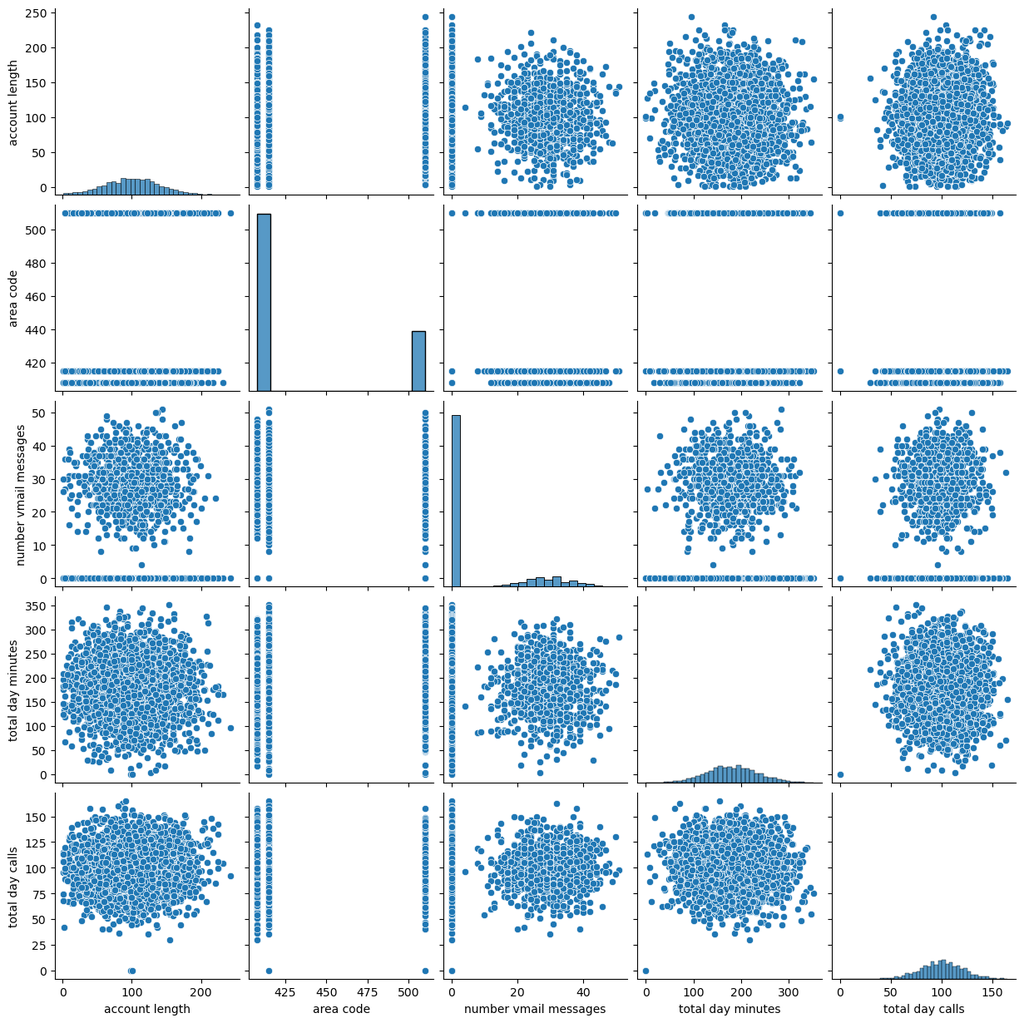

```python
# Pairplot for a subset of numeric columns (to avoid clutter)
sns.pairplot(df[numeric_columns[:5]])  # Visualize first 5 numeric columns
plt.show()
```

Target Variable Analysis: Churn

Churn Distribution

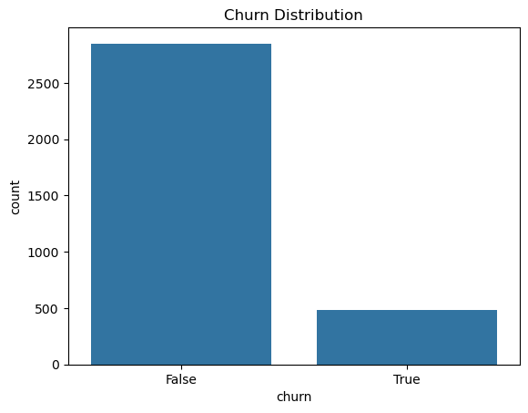

```python
# Plot churn distribution
sns.countplot(data=df, x='churn')
plt.title('Churn Distribution')
plt.show()
```